# Pull the Lever, Kronk!

1. Introduction
2. Impact of Time-Dependency
3. On Common Sense
4. Disclaimer

### Introduction

One of my close friends who I also consider to be an extremely bright individual surprised me during lunch one day. He was a portfolio manager working within a big bank and yet when it came to his personal finances, he had told me that all of his capital was invested in geared equity index products. To me this notion sounded absurd - leveraged ETFs, just as cryptocurrencies and the latest hot stock tips were the realm of investment junkies looking for a quick lottery win. Certainly not the school of thought to be pursued by the business scool educated elite who were taught 'sound' investment practices and to be selectively sceptical of too-good-to-be-true investment proposals. The problem with this line of thinking however, is that at the end of the day I was still working a 9-5 whereas my retired parents in Vietnam seemed to be surrounded by freshly minted crypto-bros proclaiming their fortunes.

Returning to my peculiar friend's confession, I badgered the point a bit further. Surely a simple performance chart would articulate my feelings - leverage is a double-edged sword and so the good times will come to nought once you overshoot the optimal Kelly during a bear market and are unable to recoup your losses (returns are geometric). Anyone who has seen a short-volatility strategy blow up might recognise this.

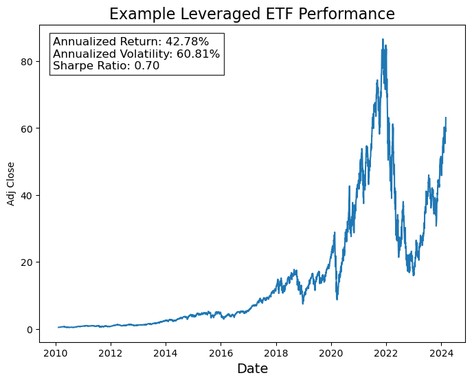

```python
import yfinance as yf
from datetime import datetime, timedelta
import seaborn as sns
import numpy as np
import warnings
import matplotlib.pyplot as plt
import pandas as pd
import random

warnings.simplefilter(action='ignore', category=FutureWarning)

priceData = yf.download('TQQQ', start='2000-01-01', end=datetime.today(), progress=False)['Adj Close']
dailyReturns = priceData.pct_change()
annReturn = (((priceData[-1] / priceData[0]) ** (365 / (priceData.index[-1] - priceData.index[0]).days)) - 1) * 100
annVolatility = dailyReturns.std() * np.sqrt(252) * 100
sharpeRatio = (annReturn / annVolatility)

plt.figure(figsize=(8, 6))
sns.lineplot(data=priceData)
plt.title('Example Leveraged ETF Performance', fontsize=16)
plt.xlabel('Date', fontsize=14)
text_box = f'Annualized Return: {annReturn:.2f}%\nAnnualized Volatility: {annVolatility:.2f}%\nSharpe Ratio: {sharpeRatio:.2f}'
plt.text(0.15, 0.85, text_box, transform=plt.gcf().transFigure,
         verticalalignment='top', horizontalalignment='left', fontsize=12, bbox=dict(facecolor='white', alpha=0.8))

plt.show()
```

### Impact of Time-Dependency

Now you might be thinking - sure, it looks good if you take the best performing index and plot it during a bull market. I would agree, so I propose the following exercise: let us produce a grid of random entry/exit points and investigate the proportion of positive vs negative period returns. Doing so results in over 90% of positively returning investment periods for the Nasdaq-100 x3. Furthermore, the periods which are negative are those in which the investment period is only for one year - chances are that this would correct itself upon longer holding periods. I have also plotted the equivalent analysis for a range of other major benchmark exposures.

```python
def getPeriodReturns(ticker, numSimulations):
    priceData = yf.download(ticker, start='2000-01-01', end=datetime.today(), progress=False)['Adj Close']
    random.seed(42)
    startDates = [priceData.index[0] + timedelta(days=random.randint(0, (priceData.index[-1] - priceData.index[0]).days)) for _ in range(numSimulations)]
    periods = [random.randint(1, 5) for _ in range(numSimulations)]
    df = pd.DataFrame()
    df['startDate'] = startDates
    df['startDate'] = pd.to_datetime(df['startDate'])
    df['timeDelta'] = periods
    df['endDate'] = df['startDate'] + pd.to_timedelta(df['timeDelta']*365, unit='D')
    df = pd.merge(df, priceData, left_on='startDate', right_index=True, suffixes=('', '_start'))
    df = pd.merge(df, priceData, left_on='endDate', right_index=True, suffixes=('', '_end'))
    df = df.rename(columns={'Adj Close': 'startPrice'})
    df = df.rename(columns={'Adj Close_end': 'endPrice'})
    df['periodReturn'] = (df['endPrice'] / df['startPrice'] - 1) * 100
    df['annReturn'] = ((1 + df['periodReturn']/100) ** (1/df['timeDelta']) - 1) * 100
    df = df.sort_values(by='annReturn', ascending=False)
    return df

df = getPeriodReturns('TQQQ', 100)
display(df)
```

|  | startDate | timeDelta | endDate | startPrice | endPrice | periodReturn | annReturn |
| --- | --- | --- | --- | --- | --- | --- | --- |
| 53 | 2023-01-23 | 1 | 2024-01-23 | 21.366549 | 55.410000 | 159.330606 | 159.330606 |
| 29 | 2019-08-05 | 1 | 2020-08-04 | 13.504023 | 30.676270 | 127.163938 | 127.163938 |
| 28 | 2013-09-10 | 1 | 2014-09-10 | 1.772008 | 3.641793 | 105.517817 | 105.517817 |
| 98 | 2016-01-20 | 2 | 2018-01-19 | 3.339342 | 13.697405 | 310.182736 | 102.529686 |
| 10 | 2019-07-30 | 2 | 2021-07-29 | 16.743126 | 65.910927 | 293.659626 | 98.408575 |
| 79 | 2016-03-02 | 2 | 2018-03-02 | 3.776589 | 13.225585 | 250.199244 | 87.136112 |
| 58 | 2016-08-08 | 1 | 2017-08-08 | 4.978101 | 9.132959 | 83.462726 | 83.462726 |
| 91 | 2022-11-01 | 1 | 2023-11-01 | 19.857405 | 34.319340 | 72.828928 | 72.828928 |
| 8 | 2012-01-24 | 3 | 2015-01-23 | 0.840774 | 4.054802 | 382.270128 | 68.952045 |
| 2 | 2016-04-13 | 5 | 2021-04-12 | 4.352127 | 52.260193 | 1100.796575 | 64.397000 |
| 31 | 2016-05-06 | 3 | 2019-05-06 | 3.740389 | 16.222427 | 333.709619 | 63.079618 |
| 18 | 2010-09-16 | 4 | 2014-09-15 | 0.515421 | 3.473853 | 573.983530 | 61.124774 |
| 46 | 2012-11-29 | 5 | 2017-11-28 | 1.076988 | 11.472533 | 965.242927 | 60.505431 |
| 97 | 2013-04-26 | 5 | 2018-04-25 | 1.263193 | 11.190254 | 785.870414 | 54.694203 |
| 1 | 2010-09-03 | 5 | 2015-09-02 | 0.457181 | 3.795705 | 730.240822 | 52.700626 |
| 3 | 2015-08-10 | 3 | 2018-08-09 | 4.843063 | 16.424196 | 239.128288 | 50.240841 |
| 11 | 2010-10-29 | 5 | 2015-10-28 | 0.664071 | 4.952477 | 645.775129 | 49.458830 |
| 76 | 2013-10-11 | 5 | 2018-10-10 | 1.844580 | 13.610363 | 637.857093 | 49.140107 |
| 92 | 2017-03-03 | 3 | 2020-03-02 | 6.937373 | 21.400511 | 208.481471 | 45.571501 |
| 86 | 2017-03-10 | 5 | 2022-03-09 | 6.986994 | 45.623119 | 552.972045 | 45.538843 |
| 4 | 2015-02-13 | 5 | 2020-02-12 | 4.345998 | 27.929977 | 542.659721 | 45.076215 |
| 20 | 2014-07-28 | 1 | 2015-07-28 | 3.314046 | 4.797915 | 44.775131 | 44.775131 |
| 95 | 2018-12-27 | 5 | 2023-12-26 | 8.887889 | 51.270000 | 476.852400 | 41.975348 |
| 73 | 2013-12-13 | 5 | 2018-12-12 | 2.248704 | 11.321225 | 403.455616 | 38.163154 |
| 47 | 2018-08-08 | 2 | 2020-08-07 | 16.438839 | 31.055319 | 88.914308 | 37.446101 |
| 69 | 2014-10-24 | 5 | 2019-10-23 | 3.453928 | 15.757951 | 356.232690 | 35.468175 |
| 54 | 2014-06-05 | 5 | 2019-06-04 | 2.869121 | 12.423503 | 333.007309 | 34.059948 |
| 96 | 2020-05-27 | 2 | 2022-05-27 | 19.563946 | 32.564186 | 66.449992 | 29.015500 |
| 78 | 2018-08-16 | 4 | 2022-08-15 | 15.840930 | 38.042095 | 140.150643 | 24.486122 |
| 67 | 2018-06-01 | 4 | 2022-05-31 | 14.274162 | 32.329422 | 126.489102 | 22.676627 |
| 33 | 2014-12-10 | 1 | 2015-12-10 | 3.947579 | 4.828828 | 22.323776 | 22.323776 |
| 93 | 2014-11-18 | 1 | 2015-11-18 | 4.002474 | 4.884144 | 22.028112 | 22.028112 |
| 37 | 2018-08-20 | 4 | 2022-08-19 | 15.806762 | 34.579277 | 118.762563 | 21.616710 |
| 65 | 2018-04-18 | 1 | 2019-04-18 | 12.956323 | 15.635720 | 20.680232 | 20.680232 |
| 44 | 2020-06-01 | 3 | 2023-06-01 | 20.490788 | 35.614120 | 73.805523 | 20.232310 |
| 30 | 2017-09-29 | 5 | 2022-09-28 | 9.294028 | 21.784454 | 134.391952 | 18.573746 |
| 52 | 2018-03-23 | 5 | 2023-03-22 | 11.422912 | 24.408680 | 113.681772 | 16.400138 |
| 90 | 2014-11-05 | 2 | 2016-11-04 | 3.747109 | 4.569734 | 21.953576 | 10.432593 |
| 43 | 2011-02-01 | 1 | 2012-02-01 | 0.856782 | 0.898201 | 4.834198 | 4.834198 |
| 14 | 2015-01-07 | 1 | 2016-01-07 | 3.743676 | 3.807094 | 1.694007 | 1.694007 |
| 13 | 2012-03-19 | 1 | 2013-03-19 | 1.187979 | 1.203022 | 1.266300 | 1.266300 |
| 62 | 2018-08-21 | 1 | 2019-08-21 | 15.970275 | 15.156578 | -5.095071 | -5.095071 |
| 57 | 2015-03-23 | 1 | 2016-03-22 | 4.525354 | 4.051139 | -10.479080 | -10.479080 |
| 68 | 2018-01-30 | 1 | 2019-01-30 | 14.235118 | 11.004169 | -22.697026 | -22.697026 |

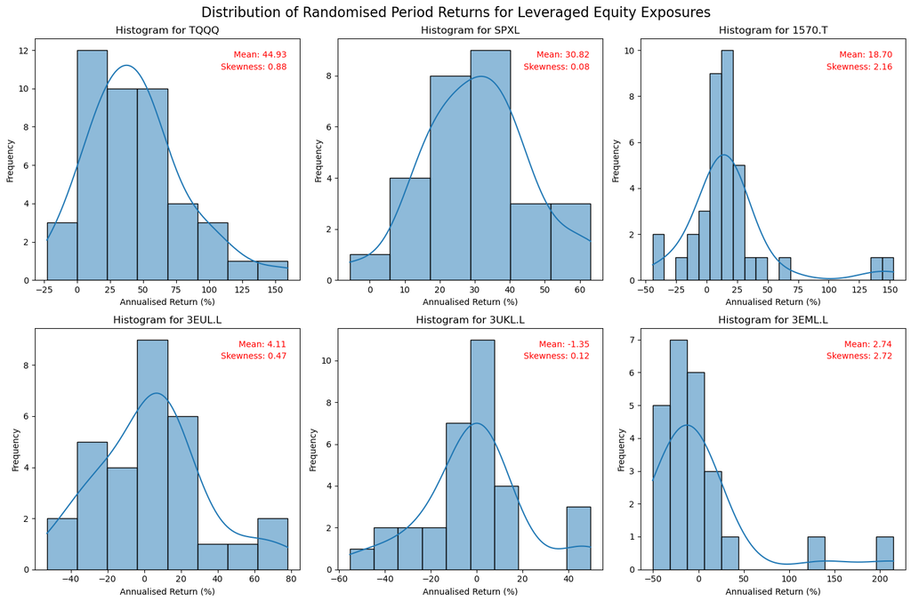

```python
tickersList = ['TQQQ','SPXL','1570.T','3EUL.L','3UKL.L','3EML.L']
fig, axes = plt.subplots(nrows=2, ncols=3, figsize=(15, 10))
axes = axes.flatten()

for i, ticker in enumerate(tickersList):
    data = getPeriodReturns(ticker, 100)['annReturn']
    average = data.mean()
    skewness = data.skew()
    sns.histplot(data, ax=axes[i], kde=True)
    axes[i].set_title(f'Histogram for {ticker}')
    axes[i].set_xlabel('Annualised Return (%)')
    axes[i].set_ylabel('Frequency')
    axes[i].text(0.95, 0.95, f'Mean: {average:.2f}', transform=axes[i].transAxes, ha='right', va='top', color='red')
    axes[i].text(0.95, 0.90, f'Skewness: {skewness:.2f}', transform=axes[i].transAxes, ha='right', va='top', color='red')

plt.suptitle('Distribution of Randomised Period Returns for Leveraged Equity Exposures', fontsize=16)
plt.tight_layout()
plt.show()
```

### On Common Sense

I once heard a saying: "common sense is the least common of senses". Perhaps senses that are common are actually not all that sensible. The understanding of the masses has shown to be easily influenced and prone to fallacious judgement historically, and yet here I am entertaining leveraged ETFs. So I wish to summarise a couple arguments as to why I think there might actually be something there:

- Major equity indices are not exactly comparable to any particular crypto asset, even if you scaled their volatilities accordingly. There is no guarantee that any asset should continue to rise in the future, however with broad equity exposures this has at least been true historically. And why shouldn't it? Economies continue to grow, new technologies are developed and our entire pension system relies on it. Major market-cap indices are efficiently designed to maintain exposure to winners and to cut out the losers - so even if we do see a sector rotation, this would eventually reflect itself in the benchmark index. The exposure is in itself a reflection of capitalism and the rise of passive investing only amplifies its lopsided gains.
- My second argument is more pragmatic - maximising exposure to beta generally increases absolute returns. Perhaps not risk-adjusted, but as the old adage goes, you can't eat Sharpe Ratio. The period returns discussed previously are hard to dispute and if there is hesitation around potentially being caught in the unlucky proportion of losing periods, dollar cost averaging with a healthy dose of patience should be remedial.
- Finally there is a high level of accessibility on reputable retail investing / ISA platforms. Sometimes I am astounded that I am unable to find certain exposures that would provide additional portfolio diversification and yet I am able to expose myself to 3x beta any time of the day.

Leveraged ETFs represent much of what I hate in this world - they are oversimplified, unacademic and lets be honest, somewhat over-the-top. However, that is me confounding my top-down judgement with a clear assessment of what may be a powerful tool to maximise asymmetrical gains in a retail-accessible manner.

### Disclaimer

This does not constitute investment advice and represents my personal, independent views.